# Lab 04

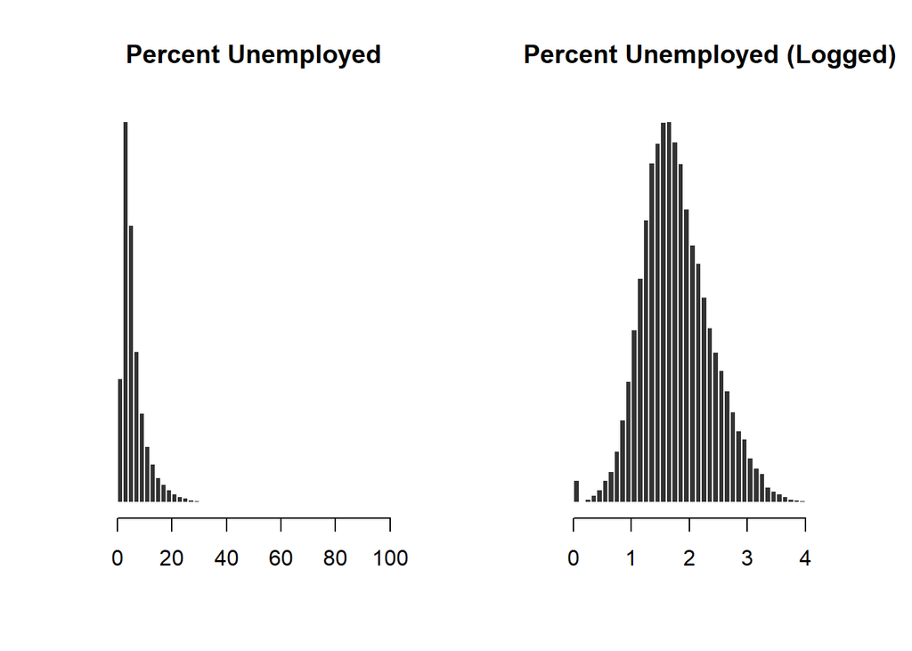

```r
#p.unemp

par(mfrow = c(1,2))

hist( d$p.unemp, breaks=50, col="gray20", border="white",
      yaxt="n", xlab="", ylab="", main="Percent Unemployed")

hist( log(d$p.unemp+1), breaks=50, col="gray20", border="white",
      yaxt="n", xlab="", ylab="", main="Percent Unemployed (Logged)")
```

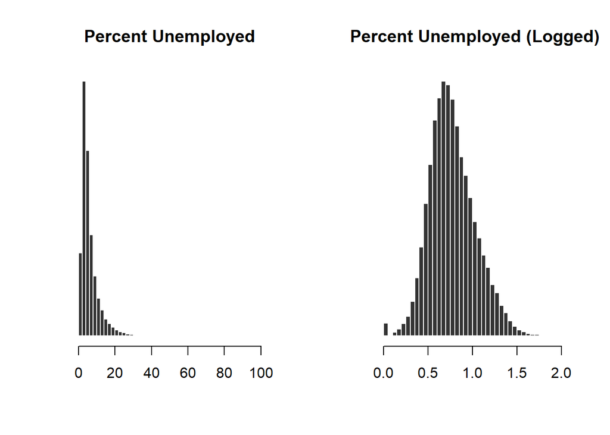

```r
log.p.unemp <- log10( d$p.unemp + 1)

par(mfrow = c(1,2))

hist( d$p.unemp, breaks=50, col="gray20", border="white",
      yaxt="n", xlab="", ylab="", main="Percent Unemployed")

hist( log.p.unemp, breaks=50, col="gray20", border="white",
      yaxt="n", xlab="", ylab="", main="Percent Unemployed (Logged)")
```

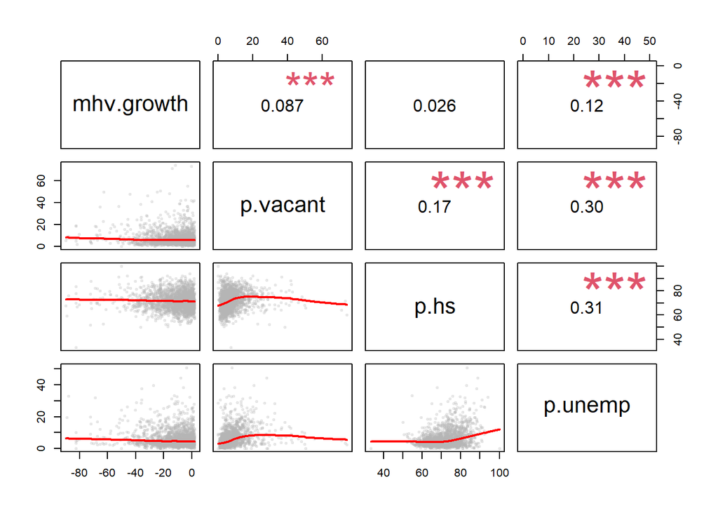

```r
# create subset to visualize in correlation matrix
d2 <- select( d, mhv.growth, p.vacant, p.hs, p.unemp)

# reduce data density for visualization
set.seed( 1234 )
d3 <- sample_n( d2, 10000 ) %>% na.omit()
# correlation plots
pairs( d3, upper.panel=panel.cor, lower.panel=panel.smooth )
```

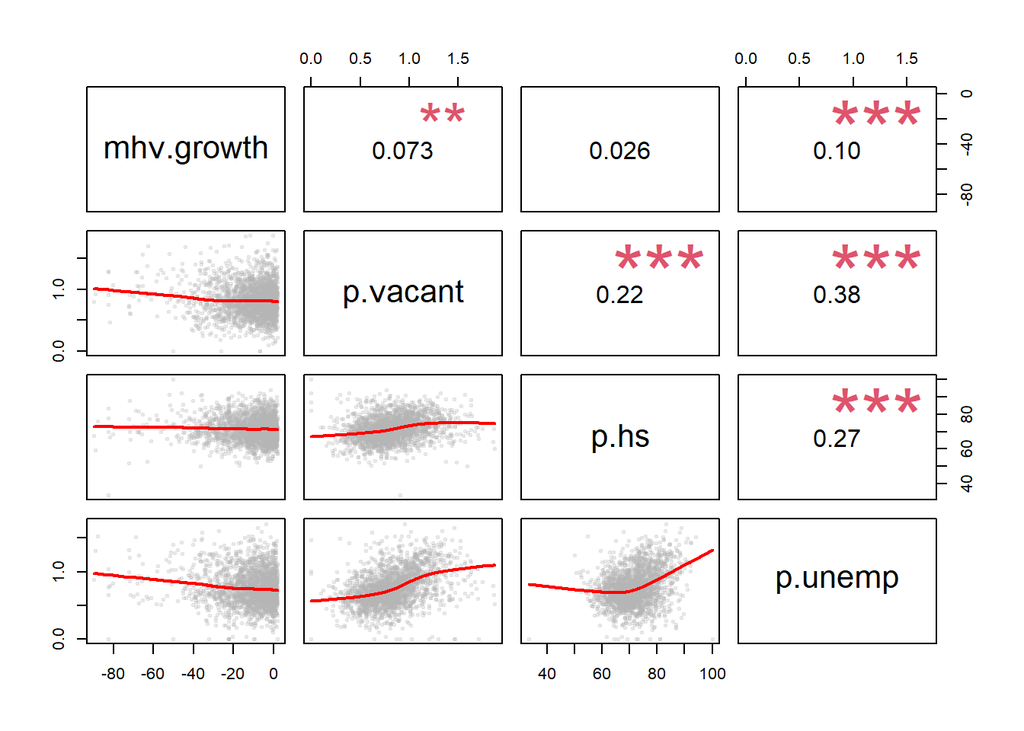

```r
# recode some vars to remove outliers and skew
d2$mhv.growth[ d2$mhv.growth > 200 ] <- NA
d2$p.vacant <- log10( d2$p.vacant + 1)
d2$p.unemp <- log10( d2$p.unemp + 1 )


# reduce data density for visualization
set.seed( 1234 )
d4 <- sample_n( d2, 10000 ) %>% na.omit()
# correlation plots
pairs( d4, upper.panel=panel.cor, lower.panel=panel.smooth )
```

#### Check for multicolinearity

A sign of multicollinarity is when both coefficients get smaller and the standard errors get bigger when the two variables are included in the same model

```r
#set up data
reg.data <- d

reg.data$mhv.growth[reg.data$mhv.growth > 200] <- NA
reg.data$p.vacant <- log10(reg.data$p.vacant + 1)
reg.data$p.unemp <- log10(reg.data$p.unemp + 1)
reg.data$p.hs <- log10(reg.data$p.hs + 1)

#check for multicolinearity: p.vacant / p.hs

m1 <- lm( mhv.growth ~ p.vacant + cbsa, data = reg.data )
m2 <- lm( mhv.growth ~ p.hs + cbsa, data = reg.data )
m4 <- lm( mhv.growth ~ p.vacant + p.hs + cbsa, data = reg.data )

stargazer( m1, m2, m4,
           type = s.type, digits = 2,
           omit.stat = c("rsq","f"),
           omit = "cbsa")
```

|  | *Dependent variable:* |  |  |
| --- | --- | --- | --- |
|  | mhv.growth |  |  |
|  | (1) | (2) | (3) |
| p.vacant | -8.19*** |  | -7.90*** |
|  | (0.47) |  | (0.48) |
| p.hs |  | -16.69*** | -7.81*** |
|  |  | (2.59) | (2.62) |
| Constant | 3.02 | 24.88*** | 17.18** |
|  | (4.78) | (6.80) | (6.74) |
| Observations | 12,098 | 12,098 | 12,098 |
| Adjusted R<sup>2</sup> | 0.26 | 0.24 | 0.26 |
| Residual Std. Error | 11.64 (df = 11757) | 11.77 (df = 11757) | 11.64 (df = 11756) |
| *Note:* | p<0.1; p<0.05; p<0.01 |  |  |

Both coefficients increased and there was no change to the standard errors to speak of. I don’t believe there’s an issue with multicollinearity.

```r
#check for multicolinearity: p.vacant / p.unemp
m3 <- lm( mhv.growth ~ p.unemp + cbsa, data = reg.data )
m5 <- lm( mhv.growth ~ p.vacant + p.unemp + cbsa, data = reg.data )

stargazer( m1, m3, m5,
           type = s.type, digits = 2,
           omit.stat = c("rsq","f"),
           omit = "cbsa")
```

|  | *Dependent variable:* |  |  |
| --- | --- | --- | --- |
|  | mhv.growth |  |  |
|  | (1) | (2) | (3) |
| p.vacant | -8.19*** |  | -6.88*** |
|  | (0.47) |  | (0.51) |
| p.unemp |  | -5.89*** | -3.33*** |
|  |  | (0.45) | (0.49) |
| Constant | 3.02 | -0.84 | 4.52 |
|  | (4.78) | (4.79) | (4.77) |
| Observations | 12,098 | 12,096 | 12,096 |
| Adjusted R<sup>2</sup> | 0.26 | 0.25 | 0.26 |
| Residual Std. Error | 11.64 (df = 11757) | 11.70 (df = 11755) | 11.61 (df = 11754) |
| *Note:* | p<0.1; p<0.05; p<0.01 |  |  |

Both coefficients got larger, and there was no real change to the standard errors. No issue with multicollinearity.

```r
#check for multicolinearity: p.unemp / p.hs
m6 <- lm( mhv.growth ~ p.unemp + p.hs + cbsa, data = reg.data )

stargazer( m3, m2, m6,
           type = s.type, digits = 2,
           omit.stat = c("rsq","f"),
           omit = "cbsa")
```

|  | *Dependent variable:* |  |  |
| --- | --- | --- | --- |
|  | mhv.growth |  |  |
|  | (1) | (2) | (3) |
| p.unemp | -5.89*** |  | -5.23*** |
|  | (0.45) |  | (0.47) |
| p.hs |  | -16.69*** | -16.57*** |
|  |  | (2.59) | (2.90) |
| Constant | -0.84 | 24.88*** | 29.30*** |
|  | (4.79) | (6.80) | (7.13) |
| Observations | 12,096 | 12,098 | 12,096 |
| Adjusted R<sup>2</sup> | 0.25 | 0.24 | 0.25 |
| Residual Std. Error | 11.70 (df = 11755) | 11.77 (df = 11757) | 11.69 (df = 11754) |
| *Note:* | p<0.1; p<0.05; p<0.01 |  |  |

Both coefficients increased (minimally for p.hs); and the standard error for p.unemp did not change much while p.hs increased a bit more. I don’t believe there’s an issue with multicolinearity

```r
m7 <- lm( mhv.growth ~ p.unemp + p.hs + p.vacant + cbsa, data = reg.data )

stargazer( m1, m2, m3, m7,
           type = s.type, digits = 2,
           omit.stat = c("rsq","f"),
           omit = "cbsa")
```

|  | *Dependent variable:* |  |  |  |
| --- | --- | --- | --- | --- |
|  | mhv.growth |  |  |  |
|  | (1) | (2) | (3) | (4) |
| p.vacant | -8.19*** |  |  | -6.61*** |
|  | (0.47) |  |  | (0.51) |
| p.hs |  | -16.69*** |  | -11.59*** |
|  |  | (2.59) |  | (2.91) |
| p.unemp |  |  | -5.89*** | -2.97*** |
|  |  |  | (0.45) | (0.49) |
| Constant | 3.02 | 24.88*** | -0.84 | 25.41*** |
|  | (4.78) | (6.80) | (4.79) | (7.09) |
| Observations | 12,098 | 12,098 | 12,096 | 12,096 |
| Adjusted R<sup>2</sup> | 0.26 | 0.24 | 0.25 | 0.26 |
| Residual Std. Error | 11.64 (df = 11757) | 11.77 (df = 11757) | 11.70 (df = 11755) | 11.61 (df = 11753) |
| *Note:* | p<0.1; p<0.05; p<0.01 |  |  |  |

#### Discussion

Explain your findings to a general audience. *Vacancy, education, and unemployment all affect the growth in home values. The three variables are each negatively correlated with increase in values, meaning as each variable increases, growth in home values decreases; each variable decreases home values. Metro-level data was taken into account when looking at the relationship, so each variable was looked to see how it affected the home value growth within its metro area, and each area aggregated. The relationship is statistically significant with a p-level of 0.05.*